# Writing_Assign_1

Jack Anthony 25067142

April 24, 2018

Microbial actions and human life are indisputably intertwined. Humans, however, are not wholly dependent the ecological catalysis of microbial life for the survival and proliferation of our species. Prokaryotic life catalyzes several important biogeochemical cycles globally, providing immense shifts in the redox states of nearly all biologically important compounds via their metabolic processes. Currently, both human activities and microbial metabolisms contribute to nutrient cycling on Earth, with microbes bearing most of the weight, but this balance is changing at an accelerating rate.

Organisms with consciousnesses have the ability to apply their efforts directionally towards a specific change. As humans, we can make plans while taking future conditions into account, we can cooperate towards a goal, and we can place a value on the success of individuals and species beyond the self. Microbes are bound by the forces of natural selection, and changes must be beneficial to an individual cell in order to be passed on to the next generation. Human consciousness gives humanity the capacity to make faster and more drastic changes to the biogeochemical landscape than microbial life.

Over the century since the industrial revolution, human industry, technology, and understanding of the universe has increased exponentially. Compared to the temporal scale that geological processes and shifts in net global microbial function occur, all of human progress is only a tiny blip on the tail end of history. Although human impact on biogeochemical cycles is minimal compared to that of prokaryotes in the present day, the pattern of exponential increase in humanity’s capacity to alter the environment, combined with recent emerging biotechnologies, makes for a compelling argument that microbes will become replaceable in the not so distant future.

The potential for human processes to excel beyond microbial processes is facilitated by consciousness. This emergent property gives humanity three main abilities that mitigate the normal evolutionary selection processes: the ability to cooperate towards a goal that may not immediately be beneficial to all contributors; the ability to take future impacts of actions into account when making current plans; and to place an innate value on the lives of humans and other species, both through compassion and through economic market forces. Together, this means that people can establish how a system functions, allocate resources towards a change in said system, and enact a plan not only to change the system in a specific direction, but to change it in what is determined to be the best direction. Conversely, changes to net prokaryotic population function, another emergent property, are determined solely by whether a small change is beneficial to the ability of an individual to reproduce. Natural selection places limits on the capacity of microbes to enact change on biogeochemical cycles compared to humans.

Both the maximum potential for change to biogeochemical cycles and the rate at which this potential can increase for microbes have boundary limits. The rate that the global, net prokaryotic metabolism can change is limited by the rate at which cells divide and the rate at which the global microbial genetic pool can be altered. Although the estimated number of prokaryotic cells on Earth is astronomically large, on the order of 10<sup>30</sup>, nearly all of them live in the terrestrial subsurface and have an average turnover rate on the scale of centuries ([Whitman *et al.*, 1998](http://www.pnas.org/content/95/12/6578)). Within geological time scales, this ‘silent majority’ is extremely active and relevant, but on the time scale of modern human environmental intervention, the division rate of these hidden cells makes their tremendous abundance much less consequential.

Cell division is also limited by energy availability. The primary input of energy to global biological systems is photosynthetic carbon fixation by higher plants and photosynthetic bacteria. The rate at which sunlight is transformed to an ecologically available energy source by a given photosynthetic population and the rate at which this energy can be disseminated to other organisms in the deep ocean and terrestrial sediment both place boundaries on the maximum global rate of microbial production. Global metabolic catalysis is dependent on the energy supplied to biological processes, and microbes have physical limitations to both maximum energy production and energy transfer between cells.

Beyond cellular division, genetic variation is necessary for changes to prokaryotic metabolic function, which in turn determines the ability for the global prokaryotic population to alter biogeochemical cycles. Horizontal gene transfer and the extremely high abundance of cells on Earth make useful mutations extremely common, even on small temporal scales. It is estimated that four simultaneous mutations occur in a cell every half hour, in the surface ocean alone ([Whitman *et al.*, 1998](http://www.pnas.org/content/95/12/6578)), however, this does not mean that the pool of available genes changes quickly. For a mutation to be heritable, it cannot be lethal. This presents a hard limit on the extent of change that can happen to genetic sequences in a single generation. Proteins vital to the survival of an individual cell, such as the metabolic enzymes relevant to many biogeochemical cycles, cannot be completely changed by mutation to a single cell in a single generation. Instead, functional diversity is the cumulative change to sequences over long time periods. Natural selection in a varied pool of random mutations is a system that strongly favours improvement to existing structures over the introduction of truly novel ones. The core set of proteins that carry out metabolic redox reactions which drive global biogeochemical cycles were developed extremely early in the history of life on Earth, and are still highly conserved ([Falkowski *et al.* 2008](https://www.ncbi.nlm.nih.gov/pubmed/18497287)). Microbial populations have boundary conditions that limit metabolic rate and functional change, imposed by both the processes of mutation and selection, and the rate of energy acquisition and distribution within a biological system. In the context of human activity, these boundaries have different limits, and may be able to be completely mitigated in the near future.

Recent history provides evidence of the potential for human activity to be the dominant controller of global nutrient cycles. Humanity has been raising the limits of energy acquisition and distribution since the first use of controlled fire, nearly 600 000 years ago ([Berna *et al.*, 2012](http://www.pnas.org/content/109/20/E1215)). The ability to obtain and use energy more efficiently has increased along with the development of human civilizations. The first agriculture marked the beginning of a steady march toward increasingly efficient conversion of sunlight to available food sources, and made the first large-scale energy distribution network necessary: the transport and trade of food. The beginning of the industrial revolution marked the shift away from human bodies as the primary means of energy conversion from chemical to other forms. Vast canal systems for coal distribution made up the second, higher throughput energy distribution system. Finally, the discovery of electricity, along with the wide scale adoption of oil as a fuel source, ushered in the third generation of power production and distribution. In modern times, vast amounts of energy are produced by a ‘metabolism’ of human activity. Electrical and chemical energy are distributed along global networks of wires, pipes, and roads.

Energy availability becomes less of a limitation to maximum human impact on biogeochemical cycles every year. At the present date, human industry already rivals the magnitude of influence on nitrogen and carbon cycling by microbial metabolisms. Atmospheric carbon dioxide measurements show that the interannual increase in carbon dioxide due to anthropogenic combustion of fossil fuels, indicating that humanity already has to power to be the deciding factor in carbon cycling but does has not yet implemented directional control ([NOAA, 2018](https://www.esrl.noaa.gov/gmd/ccgg/trends/)). Likewise, the Haber process has allowed human activity to synthetically reduce massive amounts of nitrogen gas to ammonium for use in agriculture. At the turn of the millenium, humans produced about half of all nitrogen fixed annually, and this value has been increasing exponentially since the 1940’s ([Rockstrom, 2009](https://www.nature.com/articles/461472a);[Vitousek *et al.*, 1997](http://science.sciencemag.org/content/277/5325/494.full)). Besides the conversion of organic matter to carbon dioxide, and the conversion of nitrogen gas to ammonium, human industry has the capacity to upset nearly any step in global biogeochemical cycles, should the current microbial processes become insufficient.

Man-made fixed nitrogen and carbon dioxide have both increased exponentially as global energy production has risen. However, the limitation of energy availability will not last much longer. A crude exponential fit of global energy production from 1820 to 2010 extrapolated to the year 4000 shows that humanity will consume the energy of our entire sun in just another 1800 years if production continues on the trend set since the industrial revolution (Fig. 1). In all likelihood, an element beyond energy availability, such as the maximum carrying capacity for human life on Earth, will set a new limit on human progress long before the need for a Dyson sphere is reached, but the key factor is that human energy production is virtually endless compared to the limited photosynthetic rate providing energy to microbial metabolism.

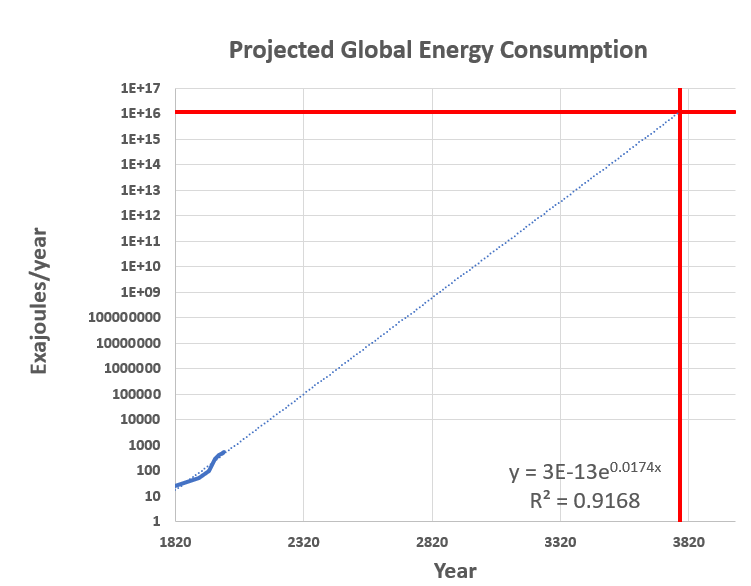

If the energy available to humans far outpaces that of microbes, the other factor at play is diversity of function and its rate of function. The human analog for the global microbial gene pool is the sum of human knowledge and available computational power. Computational power has increased exponentially since the first integrated circuits in the 1960’s. Transistor density has followed Moore’s Law by doubling every year, although this is expected to stop in the near future as transistor sizes become small enough for quantum effects to cause problems with keeping microcircuits closed ([Chien and Karamcheti, 2013]). Gallium and other alternatives to silicon are being explored to put off the end to Moore’s Law, but these are all just stopgaps and eventually transistor density must plateau due to physical limitations. However, computational power can still increase exponentially without an increase in transistor density, as long as there is enough available energy to fabricate and run more computer chips. Energy production is not likely to reach a maximum limit before Moore’s Law is terminated, meaning future computational power will be tied to energy production, a value that has been increasing exponentially for two centuries.

The human analogue to microbial genetic diversity is the diversity of technologies available. The sum of human knowledge has increased exponentially as energy availability and societal changes have allowed for greater resource allocation to research. Specifically, the science of microbiology is only in its infancy. Microbes were first observed a mere 400 years ago and medical microbiology exploded just 100 years ago. DNA was first imaged 70 years ago and molecular techniques in biology have become increasingly complex since then. Humanity’s collective understanding of how life functions, including how microbes impact geochemical cycles, has increased at an accelerating rate throughout all of human history. It is reasonable to expect that given increased energy and resources going forward in time, knowledge of biotic chemistry will continue to increase exponentially. All of human history is a raindrop in the ocean of time, where significant changes to genetic diversity and geologic equilibria have occurred. Furthermore, the period of time since people have begun to tease apart the intricacies of life on a microscopic scale is only a molecule of water in that raindrop. Right now, new human technologies can develop considerably faster than new microbial functions. Humanity is on the tipping point of making prokaryotes obsolete.

With the assumption that anthropologic energy production and knowledge of the universe will continue to increase exponentially into the next millennium, humanity is poised to make the metabolic catalysis of biogeochemical cycles by microbes unnecessary. Consciousness has allowed higher boundaries on rates of change to the environment for humans than for microbes, As evidenced by the current upsets to global carbon and nitrogen cycles. Potential for humans to alter biogeochemical processes will increase much faster than biological or geological systems will be able to adapt. The next millennium will mark the point where sufficient energy and technology will be available to humans to make prokaryotic processes antiquated and irrelevant.

Berna et al 2012 http://www.pnas.org/content/109/20/E1215 Whitman 1998 file:///C:/Users/Jack/Downloads/Whitman_WB_etal_1998_PNAS.pdf Falkowski 2008 file:///C:/Users/Jack/Downloads/Falkowski_PG_etal_2008_Science.pdf NOAA 2018 https://www.esrl.noaa.gov/gmd/ccgg/trends/ Rockstrom 2009 file:///C:/Users/Jack/Downloads/Rockstrom_J_etal_2009_Nature.pdf Vitousek et al 1997 http://science.sciencemag.org/content/277/5325/494.full Vlachogianni and Valavanidis 2013 http://pubs.sciepub.com/education/1/3/2/index.html#Figure1 Chien and Karamcheti, 2013 https://dl.acm.org/citation.cfm?id=2635529